# Single Cell Analysis Workshop book 3

# Single Cell Analysis Workshop book 3

Here we will compare the clusters in our dataset to clusters defined by other researchers in a published datasets. Unlike methods like scClassify, MetaNeighbor does not return a label for each cell, but an overall assessment or the correspondence between pairs of clusters. We will follow this protocol: https://www.ncbi.nlm.nih.gov/pmc/articles/PMC8826496/ (Procedure 2)

Load required libraries and set base path

```r
Sys.time()
```

```
## [1] "2023-05-21 10:51:28 EDT"
```

```r
library(tidyverse)
library(Seurat)
library(SingleCellExperiment)
library(MetaNeighbor)
library(anndata)
library(SeuratDisk)
library(Matrix)
library(scclusteval)
library(mclust)
setwd("C:/Users/Home/Documents/GitHub/SingleCell_Workshop/")
```

Read in and properly format the data for the Lister lab. This is an example of using data in h5ad format with Seurat.

```r
#Load as anndata, and look at the object
lister_data <- read_h5ad("data/ListerLab/Processed_data_RNA-all_full-counts-and-downsampled-CPM.h5ad")
lister_data
```

```
## AnnData object with n_obs × n_vars = 154748 × 26747
##     obs: 'batch', 'RL#', 'age', 'chem', 'concat_id', 'numerical_age', 'stage_id', 'Sex', 'Race', 'PMI', 'Brain Regions*', 'Cause of Death', 'ICD-10 Code', 'ICD-10 category', 'Oxygen/No Oxygen', 'Date-of-Collection', 'Collection_year', 'Library Prep Date', 'Library Prep Lot', 'n_genes_by_counts', …
##     var: 'gene_ids', 'feature_types', 'non-unique_names', 'n_cells_by_counts', 'mean_counts', 'log1p_mean_counts', 'pct_dropout_by_counts', 'total_counts', 'log1p_total_counts', 'n_counts', 'n_cells', 'highly_variable', 'means', 'dispersions', 'dispersions_norm'
##     uns: 'Astro_GFAP_dev-traj_colors', 'Astro_SLC1A2_dev-traj_colors', 'CCK_RELN_dev-traj_colors', 'CCK_SORCS1_dev-traj_colors', 'CCK_SYT6_dev-traj_colors', 'ID2_CSMD1_dev-traj_colors', 'L2_CUX2_LAMP5_dev-traj_colors', 'L3_CUX2_PRSS12_dev-traj_colors', 'L4_RORB_LRRK1_dev-traj_colors', 'L4_RORB_ME…
##     obsm: 'X_pca', 'X_umap'
##     layers: 'ds_norm_cts'
##     obsp: 'connectivities', 'distances'
```

```r
#Convert the basics to Seurat format, look at the object
lister_data <- CreateSeuratObject(counts = t(lister_data$X), meta.data = lister_data$obs)
lister_data
```

```
## An object of class Seurat
## 26747 features across 154748 samples within 1 assay
## Active assay: RNA (26747 features, 0 variable features)
```

```r
#Look at the major cell types and clusters, also distribution of genes and UMIs
lister_data$cell_type %>% table
```

```
## .
##           IN      Non-Neu           PN Poor-Quality
##        27561        66543        59369         1275
```

```r
lister_data$major_clust %>% table
```

```
## .
##    L2-3_CUX2      L4_RORB  L5-6_THEMIS    L5-6_TLE4       PN_dev          VIP
##        24316        14668         7713         8845         3827         6868
##          ID2   LAMP5_NOS1      CGE_dev          SST           PV    PV_SCUBE3
##         4930          837          988         7491         3848          987
##      MGE_dev        Astro          OPC        Oligo        Micro          Vas
##         1612        25053        11145        23450         5672         1223
## Poor-Quality
##         1275
```

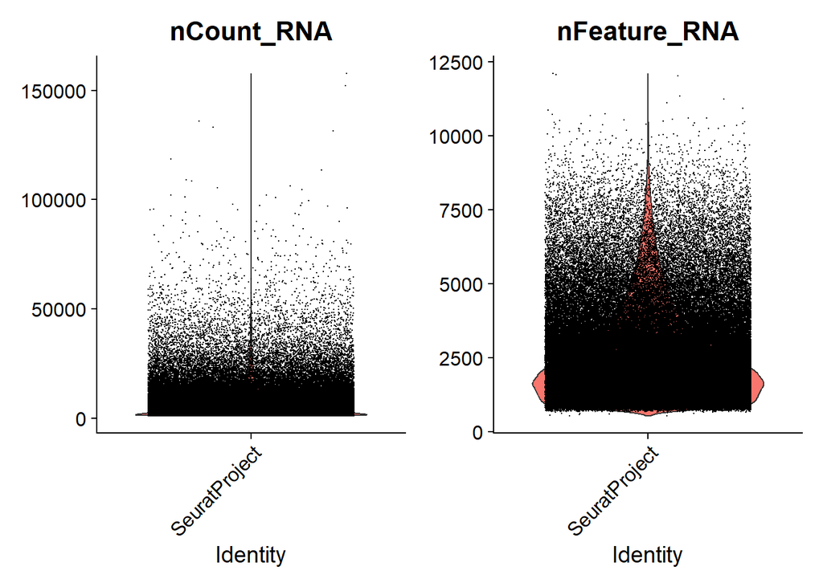

```r
VlnPlot(lister_data, features = c("nCount_RNA", "nFeature_RNA"), pt.size = 0.001)
```

[figure not shown]

```r
Idents(lister_data) <- lister_data$major_clust
VlnPlot(lister_data, features = c("SNAP25", "GAD1", "SLC17A7", "ALDH1L1", "MRC1", "PLP1", "CLDN5"), pt.size = 0.001)
```

```r
lister_data$nCount_RNA %>% summary
```

```
##    Min. 1st Qu.  Median    Mean 3rd Qu.    Max.
##    1000    2393    4209    6597    7503  157640
```

```r
lister_data$nFeature_RNA %>% summary
```

```
##    Min. 1st Qu.  Median    Mean 3rd Qu.    Max.
##     518    1483    2186    2583    3216   12091
```

Now we will train some classifiers using this object as the reference, but first we will do some pre-processing.

```r
#Normalize, find variable features, convert to SingleCellExperiment and subset to only the variable features
lister_data <- subset(lister_data, cell_type == "Non-Neu")
lister_data <- NormalizeData(lister_data, normalization.method = "LogNormalize", scale.factor = 10000)
lister_data <- FindVariableFeatures(lister_data, selection.method = "vst", nfeatures = 3000)
var_features <- VariableFeatures(lister_data)
lister_data <- as.SingleCellExperiment(lister_data)
lister_data <- lister_data[var_features,]
lister_data
```

```
## class: SingleCellExperiment
## dim: 3000 66543
## metadata(0):
## assays(2): counts logcounts
## rownames(3000): ATP1B3 FLT1 ... SLC7A8 RP3-518E13.2
## rowData names(0):
## colnames(66543): AAACCTGCAAGGACTG-RL1612_34d_v2
##   AAACCTGGTTACGCGC-RL1612_34d_v2 ... TTTGTTGCACAAGCTT-RL2132_25yr_v3
##   TTTGTTGGTAAGGTCG-RL2132_25yr_v3
## colData names(100): orig.ident nCount_RNA ... mj_dev_traj_Poor.Quality
##   ident
## reducedDimNames(0):
## mainExpName: RNA
## altExpNames(0):
```

Time to train the model!

```r
pretrained_model_major_cluster = MetaNeighbor::trainModel(
 var_genes = rownames(lister_data),
 dat = lister_data,
 study_id = rep("Lister", dim(lister_data)[2]),
 cell_type = lister_data$major_clust
)
```

Remove the Lister lab object, and load our integrated Seurat object

```r
rm(lister_data)
integrated_seurat <- readRDS("integrated_seurat.Rds")
integrated_seurat <- as.SingleCellExperiment(integrated_seurat)
```

Classify using the major clusters and plot results

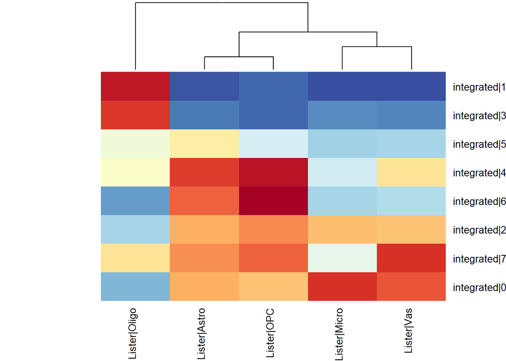

```r
#One versus all
aurocs = MetaNeighborUS(
 trained_model = pretrained_model_major_cluster, dat = integrated_seurat,
 study_id = rep("integrated", dim(integrated_seurat)[2]),
 cell_type = integrated_seurat$integrated_snn_res.0.4,
 fast_version = TRUE
)
tryCatch({plotHeatmapPretrained(aurocs, margins = c(5,5))}, error = function(error_condition) {})
```

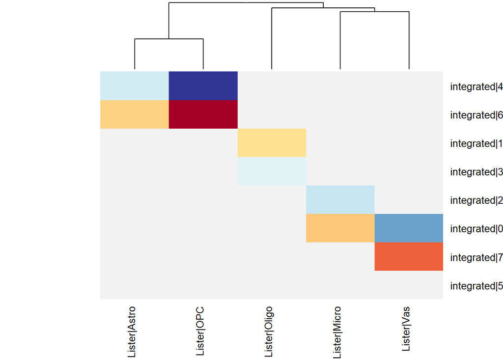

```r
#One versus best
best_hits = MetaNeighborUS(
 trained_model = pretrained_model_major_cluster, dat = integrated_seurat,
 study_id = rep("integrated", dim(integrated_seurat)[2]),
 cell_type = integrated_seurat$integrated_snn_res.0.4,
 one_vs_best = TRUE,
 fast_version = TRUE
)
tryCatch({plotHeatmapPretrained(best_hits, margins = c(5,5))},
         error = function(error_condition) {})
```

Compare labels obtained with supervised classification of cells and unsupervised clustering, also between the two supervised clustering labels

```r
 integrated_seurat <- readRDS("integrated_seurat.Rds")
 plot1 <- PairWiseJaccardSetsHeatmap(Idents(integrated_seurat), integrated_seurat$Karolinski)
 adjustedRandIndex(Idents(integrated_seurat), integrated_seurat$Karolinski) %>% print
```

```
## [1] 0.4471718
```

```r
 #plot1
 plot2 <- PairWiseJaccardSetsHeatmap(Idents(integrated_seurat), integrated_seurat$Nowakowski)
 adjustedRandIndex(Idents(integrated_seurat), integrated_seurat$Nowakowski) %>% print
```

```
## [1] 0.3989508
```

```r
 #plot2
 plot3 <- PairWiseJaccardSetsHeatmap(integrated_seurat$Karolinski, integrated_seurat$Nowakowski)
 adjustedRandIndex(integrated_seurat$Karolinski, integrated_seurat$Nowakowski) %>% print
```

```
## [1] 0.8101165
```

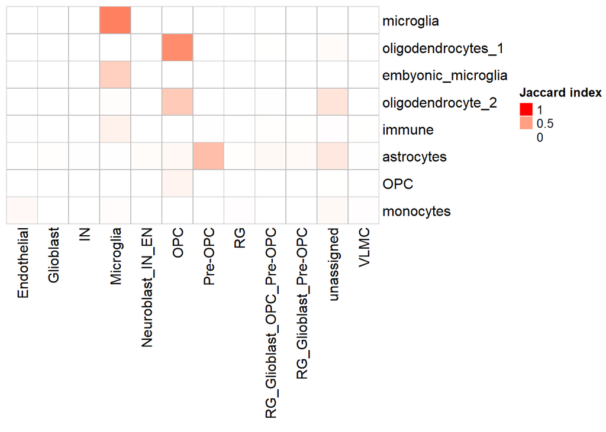

```r
 #pdf(file = "C:/Users/Home/Documents/GitHub/SingleCell_Workshop/JaccardIndexPlots.pdf", onefile = TRUE)
  plot1
```

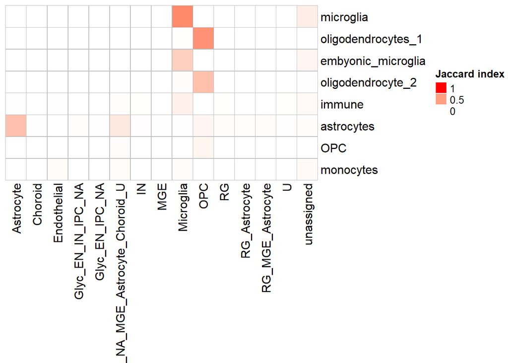

```r
  plot2
```

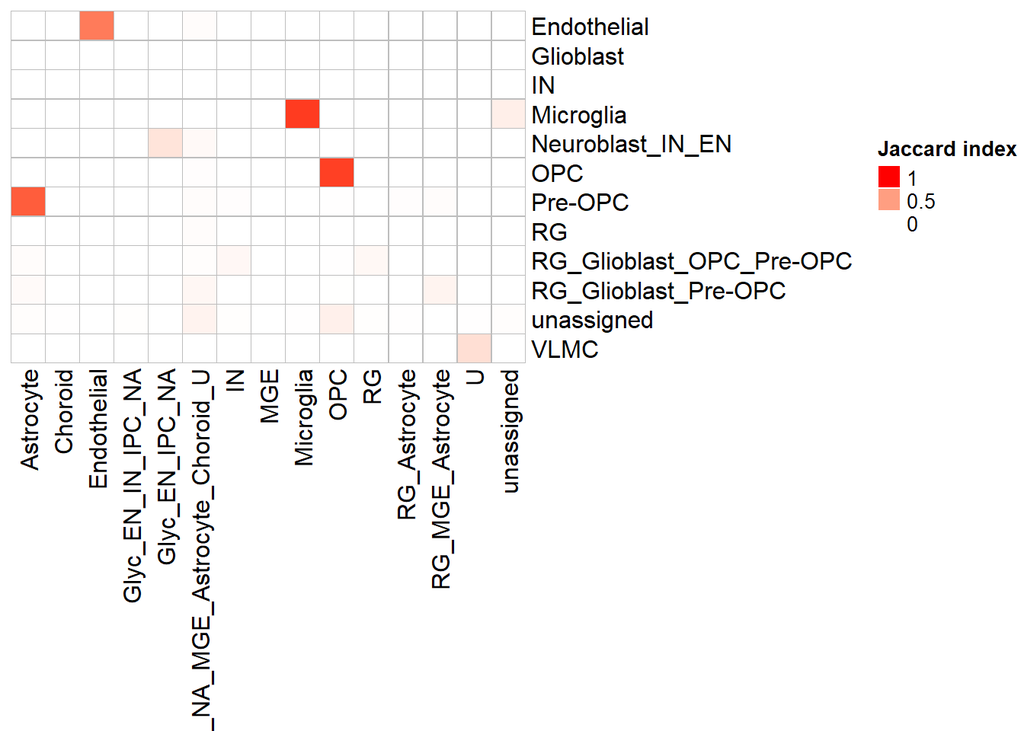

```r
  plot3
```

```r
 #dev.off()
```

Assess doublets and cell cycle genes per annotated

```r
table(integrated_seurat$age, integrated_seurat$DF.classifications_0.25_0.09_533)
```

```
##
##      Doublet Singlet
##   14     533    6568
##   41       0       0
```

```r
table(integrated_seurat$age, integrated_seurat$DF.classifications_0.25_0.17_146)
```

```
##
##      Doublet Singlet
##   14       0       0
##   41     146    1797
```

```r
#Make one variable with all the doublet classifications
integrated_seurat$DF_all <- integrated_seurat$DF.classifications_0.25_0.09_533
integrated_seurat$DF_all[integrated_seurat$age == 41] <- integrated_seurat$DF.classifications_0.25_0.17_146[integrated_seurat$age == 41]

#Make one variable with all the pANN scores
integrated_seurat$pANN_all <- integrated_seurat$pANN_0.25_0.09_533
integrated_seurat$pANN_all[integrated_seurat$age == 41] <- integrated_seurat$pANN_0.25_0.17_146[integrated_seurat$age == 41]

#Plot doublet classifications and pANN scores
table(integrated_seurat$DF_all)
```

```
##
## Doublet Singlet
##     679    8365
```

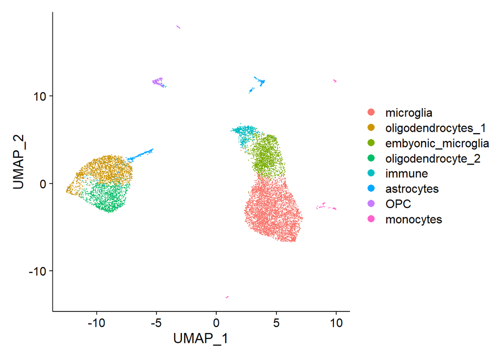

```r
UMAPPlot(integrated_seurat)
```

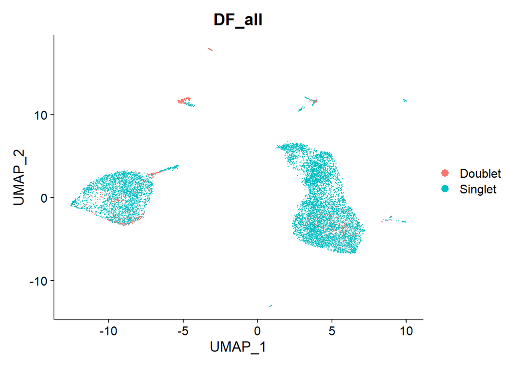

```r
UMAPPlot(integrated_seurat,  group.by = c("DF_all"))
```

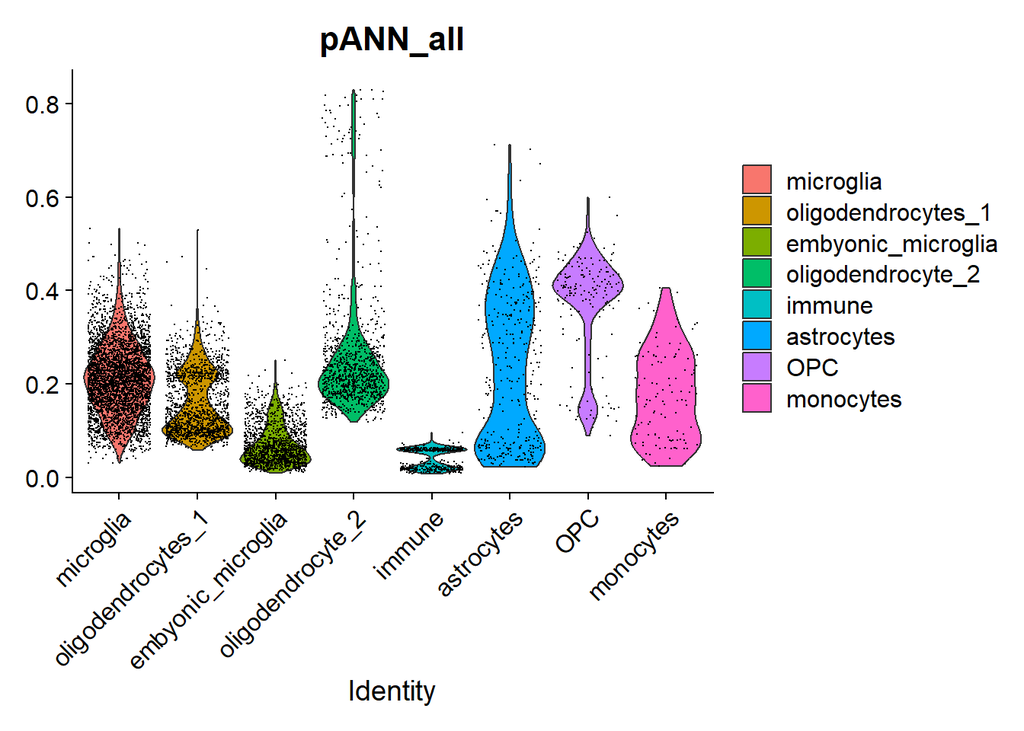

```r
VlnPlot(integrated_seurat, features = c("pANN_all"), pt.size = 0.001)
```

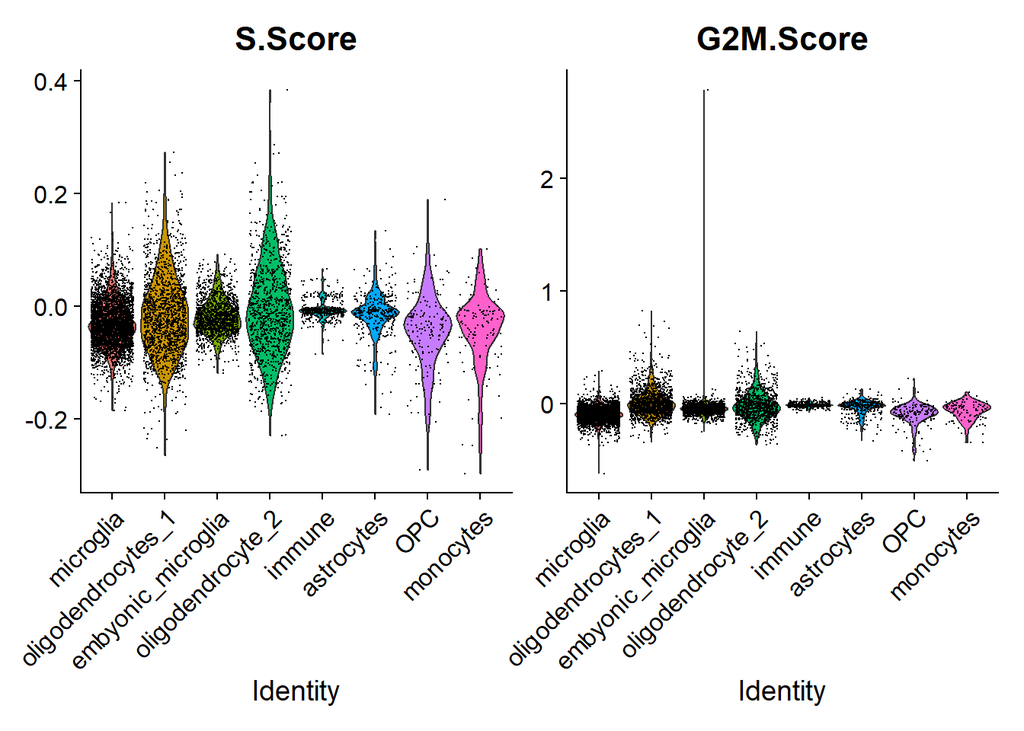

```r
#Plot CellCycle scores per cluster
VlnPlot(integrated_seurat, features = c("S.Score", "G2M.Score"))
```

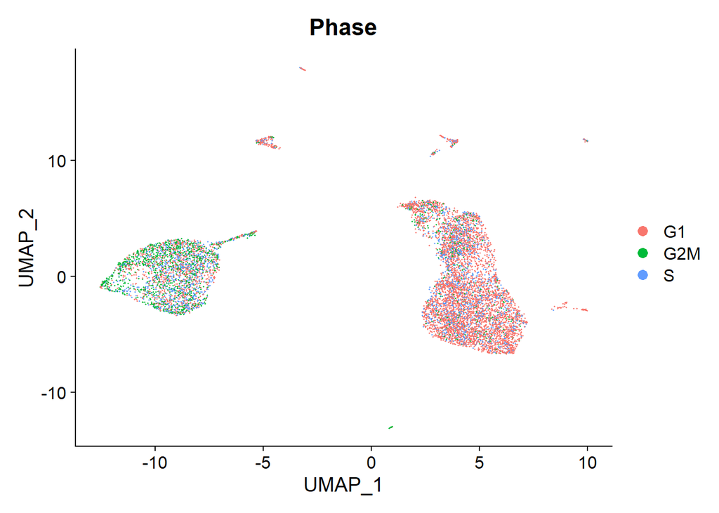

```r
UMAPPlot(integrated_seurat, group.by = "Phase")
```

Generate counts summed by or averaged by sample and cluster

```r
Idents(integrated_seurat) <- paste(Idents(integrated_seurat), integrated_seurat$age, sep = ".")
aggregated_seurat <- AggregateExpression(integrated_seurat, assays = "RNA", slot = "counts", group.by = )
aggregated_seurat$RNA %>% head
```

```
##            microglia.14 oligodendrocyte_2.14 immune.14 embyonic_microglia.14
## AL627309.1            4                    2         0                     1
## AL669831.5          134                  102         1                    38
## FAM87B               20                    0         0                     1
## LINC00115           119                    9         0                    27
## FAM41C               62                   17         0                    11
## AL645608.3            4                    0         0                     0
##            oligodendrocytes_1.14 astrocytes.14 OPC.14 monocytes.14 immune.41
## AL627309.1                     6             0      0            0         0
## AL669831.5                   106            12     10            1         0
## FAM87B                         0             0      0            0         0
## LINC00115                     19             0      7            0         0
## FAM41C                        26             3      1            2         1
## AL645608.3                     0             0      2            1         0
##            oligodendrocytes_1.41 microglia.41 oligodendrocyte_2.41
## AL627309.1                     6            0                    3
## AL669831.5                    29           40                   13
## FAM87B                         0            4                    0
## LINC00115                     11           20                    5
## FAM41C                        10           24                    6
## AL645608.3                     2            3                    0
##            embyonic_microglia.41 monocytes.41 OPC.41 astrocytes.41
## AL627309.1                     2            0      0             0
## AL669831.5                    14            2      0             1
## FAM87B                         1            0      0             0
## LINC00115                     14            2      0             0
## FAM41C                        12            0      0             1
## AL645608.3                     2            0      0             0
```

```r
aggregated_seurat$RNA %>% colSums
```

```
##          microglia.14  oligodendrocyte_2.14             immune.14
##               9921771               5528412                111095
## embyonic_microglia.14 oligodendrocytes_1.14         astrocytes.14
##               1790789               6370826                555667
##                OPC.14          monocytes.14             immune.41
##                634253                168710                132942
## oligodendrocytes_1.41          microglia.41  oligodendrocyte_2.41
##               2421835               2809643               1416351
## embyonic_microglia.41          monocytes.41                OPC.41
##                794112                158601                 31990
##         astrocytes.41
##                 79893
```

```r
average_seurat <- AverageExpression(integrated_seurat, assays = "RNA", slot = "counts", group.by = )
average_seurat$RNA %>% head
```

```
##            microglia.14 oligodendrocyte_2.14   immune.14 embyonic_microglia.14
## AL627309.1  0.001247272           0.00239521 0.000000000          0.0008710801
## AL669831.5  0.041783598           0.12215569 0.004444444          0.0331010453
## FAM87B      0.006236358           0.00000000 0.000000000          0.0008710801
## LINC00115   0.037106330           0.01077844 0.000000000          0.0235191638
## FAM41C      0.019332710           0.02035928 0.000000000          0.0095818815
## AL645608.3  0.001247272           0.00000000 0.000000000          0.0000000000
##            oligodendrocytes_1.14 astrocytes.14      OPC.14 monocytes.14
## AL627309.1           0.004950495    0.00000000 0.000000000   0.00000000
## AL669831.5           0.087458746    0.04460967 0.064102564   0.02040816
## FAM87B               0.000000000    0.00000000 0.000000000   0.00000000
## LINC00115            0.015676568    0.00000000 0.044871795   0.00000000
## FAM41C               0.021452145    0.01115242 0.006410256   0.04081633
## AL645608.3           0.000000000    0.00000000 0.012820513   0.02040816
##              immune.41 oligodendrocytes_1.41 microglia.41 oligodendrocyte_2.41
## AL627309.1 0.000000000            0.01608579  0.000000000           0.01595745
## AL669831.5 0.000000000            0.07774799  0.061538462           0.06914894
## FAM87B     0.000000000            0.00000000  0.006153846           0.00000000
## LINC00115  0.000000000            0.02949062  0.030769231           0.02659574
## FAM41C     0.004166667            0.02680965  0.036923077           0.03191489
## AL645608.3 0.000000000            0.00536193  0.004615385           0.00000000
##            embyonic_microglia.41 monocytes.41 OPC.41 astrocytes.41
## AL627309.1           0.005747126   0.00000000      0    0.00000000
## AL669831.5           0.040229885   0.03076923      0    0.01333333
## FAM87B               0.002873563   0.00000000      0    0.00000000
## LINC00115            0.040229885   0.03076923      0    0.00000000
## FAM41C               0.034482759   0.00000000      0    0.01333333
## AL645608.3           0.005747126   0.00000000      0    0.00000000
```

```r
average_seurat$RNA %>% colSums
```

```
##          microglia.14  oligodendrocyte_2.14             immune.14
##             3093.7858             6620.8527              493.7556
## embyonic_microglia.14 oligodendrocytes_1.14         astrocytes.14
##             1559.9207             5256.4571             2065.6766
##                OPC.14          monocytes.14             immune.41
##             4065.7244             3443.0612              553.9250
## oligodendrocytes_1.41          microglia.41  oligodendrocyte_2.41
##             6492.8552             4322.5277             7533.7819
## embyonic_microglia.41          monocytes.41                OPC.41
##             2281.9310             2440.0154             7997.5000
##         astrocytes.41
##             1065.2400
```

Do some house-keeping

```r
print(summary(warnings()))
```

```
## Length  Class   Mode
##      0   NULL   NULL
```

```r
Sys.time()
```

```
## [1] "2023-05-21 11:00:02 EDT"
```